# Summer Flounder Test

Sarah Gaichas

2026-06-24

# Make a summer flounder model

## WHAM from ASAP?

Use an old ASAP file from the rec_measures MSE to get started. This thing has 20 indices. What could go wrong?

Try reading the ASAP file into WHAM:

```r
mod.dir="sf-test"
write.dir <- here::here(sprintf("WHAMfits/%s/", mod.dir))
dir.create(write.dir)

sfasap <- wham::read_asap3_dat(here::here("assessments/F2021_2019_V1_MCMC.dat"))
inputsf <- wham::prepare_wham_input(sfasap)

mod <- fit_wham(inputsf, do.proj=FALSE,do.osa = TRUE,do.retro = TRUE,do.check = T,do.sdrep = TRUE)
saveRDS(mod,file=file.path(write.dir,paste0(mod.dir,".rds")))
plot_wham_output(mod, dir.main=file.path(write.dir),out.type="png")
```

That actually ran and produced output, gives the right trends

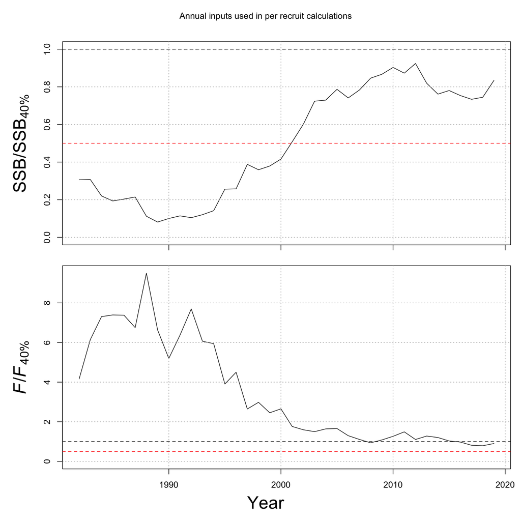

```r
knitr::include_graphics(here::here("WHAMfits/sf-test/plots_png/ref_points/FSPR_relative.png"))
```

Convergence? no

```r
mod <- readRDS(here::here("WHAMfits/sf-test/sf-test.rds"))
wham::check_convergence(mod)
```

```
## stats:nlminb thinks the model has NOT converged: mod$opt$convergence != 0
```

```
## Maximum gradient component:2.87e+01
```

```
## Max gradient parameter:F_pars
```

```
## TMB:sdreport() was performed for this model, but it appears hessian was not invertible
```

We’ll need to simplify this

What if the output SSB with noise is the biomass index input, or just use output NAA as input?

This is the output NAA 1982-2019

```r
sfNAA <- readRDS(here::here("WHAMfits/sf-test/res_tables/stock_1_region_1_NAA_table.RDS"))

sfNAA
```

```
##             1         2        3          4          5          6          7
## 1982 81295.51 54611.657 28016.53  3616.8877  1248.3736  383.31028  186.99987
## 1983 98291.50 61317.539 28239.34  9698.9717  1266.7645  437.25551  134.26132
## 1984 44563.51 73209.024 25578.40  6650.5128  2311.8037  301.96054  104.23190
## 1985 75818.59 33194.079 29923.37  5367.6378  1414.3963  491.72443   64.23005
## 1986 78279.10 56472.755 13406.22  5977.8209  1085.1798  285.97415   99.42394
## 1987 50689.15 58041.450 21447.95  2507.1300  1133.0430  205.70355   54.21014
## 1988 12548.72 37643.553 22604.83  4156.9552   492.7498  222.71327   40.43505
## 1989 36257.84  9251.715 12631.13  3017.0630   564.5638   66.94761   30.26214
## 1990 43021.21 26455.385  3449.83  2182.9467   594.0285  112.28392   13.34504
## 1991 46629.12 31363.972 11048.71   935.2735   689.6953  189.92451   35.99505
## 1992 46003.17 34484.274 12716.33  2592.8595   229.9963  170.07435   46.86341
## 1993 43749.74 32528.216 10992.43  2195.7413   579.5884   52.48964   38.99434
## 1994 58588.53 31974.830 12525.38  2661.7537   585.3271  155.54500   14.10794
## 1995 78809.10 42421.450 12139.99  2864.6191   716.2544  159.50887   42.50766
```

[output cut: 63 more lines]

## From original risk policy MSE code?

Or what if we started with John Wiedenmann’s summer flounder setup? This code is local, don’t have permission to post in a public repo

Successfully compiled and ran his code for summer flounder.

First build the operating model No changes made to the abc_opmodel.tpl or .dat files sent In terminal:

```
Sarahs-Air:summer_flounder_for_Sarah sarahgaichas$ admb abc_opmodel

*** Parse: abc_opmodel.tpl
tpl2cpp abc_opmodel || tpl2rem abc_opmodel

*** Compile: abc_opmodel.cpp
c++ -c -std=c++17 -O3 -D_USE_MATH_DEFINES -DUSE_ADMB_CONTRIBS -I. -I"/usr/local/admb/include" -I"/usr/local/admb/include/contrib" -oabc_opmodel.obj abc_opmodel.cpp

*** Linking: abc_opmodel.obj
c++ -std=c++17 -O3 -oabc_opmodel abc_opmodel.obj "/usr/local/admb/lib/libadmb-contrib-arm64-macos-clang.a"

Successfully built executable.
```

Also compile the estimation model in terminal:

```
Sarahs-Air:summer_flounder_for_Sarah sarahgaichas$ admb em_cf_selex
*** Parse: em_cf_selex.tpl
tpl2cpp em_cf_selex || tpl2rem em_cf_selex

*** Compile: em_cf_selex.cpp
c++ -c -std=c++17 -O3 -D_USE_MATH_DEFINES -DUSE_ADMB_CONTRIBS -I. -I"/usr/local/admb/include" -I"/usr/local/admb/include/contrib" -oem_cf_selex.obj em_cf_selex.cpp

em_cf_selex.cpp:598:9: warning: assigning field to itself [-Wself-assign-field]
                                        FL = FL;
                                           ^
em_cf_selex.cpp:605:9: warning: assigning field to itself [-Wself-assign-field]
                                        FU = FU;
                                           ^
2 warnings generated.
*** Linking: em_cf_selex.obj
c++ -std=c++17 -O3 -oem_cf_selex em_cf_selex.obj "/usr/local/admb/lib/libadmb-contrib-arm64-macos-clang.a"

Successfully built executable.
```

Run the om

```
Sarahs-Air:summer_flounder_for_Sarah sarahgaichas$ ./abc_opmodel
rm: assessment_estimates.txt: No such file or directory
rm: terminal_estimates_sf.txt: No such file or directory
rm: obs_est_sf.txt: No such file or directory
rm: time_varying_params.txt: No such file or directory
mr= 1 sa interval = 2 data lag = 1 i= 1 Seed 13 cr = 2 remainder  = 0
mr= 1 sa interval = 2 data lag = 1 i= 2 Seed 14 cr = 2 remainder  = 0
mr= 1 sa interval = 2 data lag = 1 i= 3 Seed 16 cr = 2 remainder  = 0
mr= 1 sa interval = 2 data lag = 1 i= 4 Seed 19 cr = 2 remainder  = 0
mr= 1 sa interval = 2 data lag = 1 i= 5 Seed 23 cr = 2 remainder  = 0
mr= 1 sa interval = 2 data lag = 1 i= 6 Seed 28 cr = 2 remainder  = 0
mr= 1 sa interval = 2 data lag = 1 i= 7 Seed 34 cr = 2 remainder  = 0
mr= 1 sa interval = 2 data lag = 1 i= 8 Seed 41 cr = 2 remainder  = 0
mr= 1 sa interval = 2 data lag = 1 i= 9 Seed 49 cr = 2 remainder  = 0
mr= 1 sa interval = 2 data lag = 1 i= 10 Seed 58 cr = 2 remainder  = 0
mr= 1 sa interval = 2 data lag = 1 i= 11 Seed 68 cr = 2 remainder  = 0
mr= 1 sa interval = 2 data lag = 1 i= 12 Seed 79 cr = 2 remainder  = 0
mr= 1 sa interval = 2 data lag = 1 i= 13 Seed 91 cr = 2 remainder  = 0
mr= 1 sa interval = 2 data lag = 1 i= 14 Seed 104 cr = 2 remainder  = 0
mr= 1 sa interval = 2 data lag = 1 i= 15 Seed 118 cr = 2 remainder  = 0
mr= 1 sa interval = 2 data lag = 1 i= 16 Seed 133 cr = 2 remainder  = 0
mr= 1 sa interval = 2 data lag = 1 i= 17 Seed 149 cr = 2 remainder  = 0
mr= 1 sa interval = 2 data lag = 1 i= 18 Seed 166 cr = 2 remainder  = 0
mr= 1 sa interval = 2 data lag = 1 i= 19 Seed 184 cr = 2 remainder  = 0
mr= 1 sa interval = 2 data lag = 1 i= 20 Seed 203 cr = 2 remainder  = 0
Model finished!
```

Files produced: /Users/sarahgaichas/Documents/Work/MAFMCindicators/summer_flounder_for_Sarah/output_for_cyrus.txt /Users/sarahgaichas/Documents/Work/MAFMCindicators/summer_flounder_for_Sarah/performance_measures_sf.txt /Users/sarahgaichas/Documents/Work/MAFMCindicators/summer_flounder_for_Sarah/em_cf_selex.log /Users/sarahgaichas/Documents/Work/MAFMCindicators/summer_flounder_for_Sarah/junk.txt /Users/sarahgaichas/Documents/Work/MAFMCindicators/summer_flounder_for_Sarah/assessment_estimates.txt /Users/sarahgaichas/Documents/Work/MAFMCindicators/summer_flounder_for_Sarah/term_est.txt /Users/sarahgaichas/Documents/Work/MAFMCindicators/summer_flounder_for_Sarah/em_cf_selex.rep /Users/sarahgaichas/Documents/Work/MAFMCindicators/summer_flounder_for_Sarah/em_cf_selex.bar /Users/sarahgaichas/Documents/Work/MAFMCindicators/summer_flounder_for_Sarah/em_cf_selex.par /Users/sarahgaichas/Documents/Work/MAFMCindicators/summer_flounder_for_Sarah/fmin.log /Users/sarahgaichas/Documents/Work/MAFMCindicators/summer_flounder_for_Sarah/em_cf_selex.dat /Users/sarahgaichas/Documents/Work/MAFMCindicators/summer_flounder_for_Sarah/BRPs_sf.txt /Users/sarahgaichas/Documents/Work/MAFMCindicators/summer_flounder_for_Sarah/performance_measures_head_sf.txt